# R_RNAseq

by adding `fig.path = 'figures/'` we put all of the figures created when we knit this document into a directory called `figures`

Install packages:

```r
#if (!requireNamespace("BiocManager", quietly = TRUE))
#    install.packages("BiocManager") # calls the package from the source

#BiocManager::install("DESeq2")
#install.packages("tidyverse")
#install.packages("ggplot2")
#install.packages("treemap")
#install.packages("devtools")
#BiocManager::install("clusterProfiler")
#install.packages("RColorBrewer")
#install.packages("pheatmap")
#devtools::install_github("karthik/wesanderson")
#BiocManager::install("topGO")
#BiocManager::install("org.Sc.sgd.db")
#BiocManager::install("Rgraphviz")
#BiocManager::install("biomaRt")
```

Load Libraries:

```r
library(DESeq2)
library(tidyverse)
library(ggplot2)
library(treemap)
library(devtools)
library(clusterProfiler)
library(RColorBrewer)
library(pheatmap)
library(topGO)
library(org.Sc.sgd.db)
library(Rgraphviz)
library(scales)
```

# 1 Differential Expression Testing

We will analyse RNA-Seq data with DESeq2 package: http://bioconductor.org/packages/devel/bioc/vignettes/DESeq2/inst/doc/DESeq2.html

The package DESeq2 provides methods to test for differential expression by use of negative binomial generalized linear models; the estimates of dispersion and logarithmic fold changes incorporate data-driven prior distributions.

Import sample metadata:

```r
# read the sample.scv file
samples <- read_csv("samples.scv")
# look at the first 6 lines
samples
```

```
## # A tibble: 6 x 3
##   sample    quant_file                 condition
##   <chr>     <chr>                      <chr>
## 1 ERR458493 htseq_counts/ERR493.counts wt
## 2 ERR458494 htseq_counts/ERR494.counts wt
## 3 ERR458495 htseq_counts/ERR495.counts wt
## 4 ERR458500 htseq_counts/ERR500.counts snf2
## 5 ERR458501 htseq_counts/ERR501.counts snf2
## 6 ERR458502 htseq_counts/ERR502.counts snf2
```

Read directory:

```r
directory <- "htseq_counts"
directory
```

```
## [1] "htseq_counts"
```

Load htseq counts:

```r
dataFiles <- grep("counts",list.files(directory),value=TRUE)
dataTable <- data.frame(sampleName = samples$sample,
                        fileName = dataFiles,
                        condition = samples$condition,
                        sample = samples$sample,
                        stringsAsFactors = default.stringsAsFactors())
dataTable$condition <- factor(dataTable$condition)
dataTable
```

```
##   sampleName      fileName condition    sample
## 1  ERR458493 ERR493.counts        wt ERR458493
## 2  ERR458494 ERR494.counts        wt ERR458494
## 3  ERR458495 ERR495.counts        wt ERR458495
## 4  ERR458500 ERR500.counts      snf2 ERR458500
## 5  ERR458501 ERR501.counts      snf2 ERR458501
## 6  ERR458502 ERR502.counts      snf2 ERR458502
```

Make a DESeq2 object:

```r
ddsHTSeq <- DESeqDataSetFromHTSeqCount(sampleTable = dataTable,
                                       directory = directory,
                                       design= ~ condition)
ddsHTSeq
```

```
## class: DESeqDataSet
## dim: 7127 6
## metadata(1): version
## assays(1): counts
## rownames(7127): ETS1-1 ETS1-2 ... tY(GUA)O tY(GUA)Q
## rowData names(0):
## colnames(6): ERR458493 ERR458494 ... ERR458501 ERR458502
## colData names(2): condition sample
```

```r
head(assay(ddsHTSeq), 6)
```

```
##        ERR458493 ERR458494 ERR458495 ERR458500 ERR458501 ERR458502
## ETS1-1         0         0         0         0         0         0
## ETS1-2         0         0         0         0         0         0
## ETS2-1         0         0         0         0         0         0
## ETS2-2         0         0         0         0         0         0
## HRA1           3         0         0         2         1         1
## ICR1          10         9         9        12        25        36
```

```r
ddsHTSeq$condition
```

```
## [1] wt   wt   wt   snf2 snf2 snf2
## Levels: snf2 wt
```

Relevel to make wild-type the reference to which expression in treatment samples is compared to:

```r
ddsHTSeq$condition <- relevel(ddsHTSeq$condition, ref = "wt")
ddsHTSeq$condition
```

```
## [1] wt   wt   wt   snf2 snf2 snf2
## Levels: wt snf2
```

Run DESeq2:

```r
ddsHTSeq <- DESeq(ddsHTSeq)
```

```
## -- note: fitType='parametric', but the dispersion trend was not well captured by the
##    function: y = a/x + b, and a local regression fit was automatically substituted.
##    specify fitType='local' or 'mean' to avoid this message next time.
```

Check out results:

```r
res <- results(ddsHTSeq, name=resultsNames(ddsHTSeq)[2])
head(res)
```

```
## log2 fold change (MLE): condition snf2 vs wt
## Wald test p-value: condition snf2 vs wt
## DataFrame with 6 rows and 6 columns
##         baseMean log2FoldChange     lfcSE      stat    pvalue      padj
##        <numeric>      <numeric> <numeric> <numeric> <numeric> <numeric>
## ETS1-1   0.00000             NA        NA        NA        NA        NA
## ETS1-2   0.00000             NA        NA        NA        NA        NA
## ETS2-1   0.00000             NA        NA        NA        NA        NA
## ETS2-2   0.00000             NA        NA        NA        NA        NA
## HRA1     1.16902      -0.742122  1.739054 -0.426739  0.669569        NA
## ICR1    14.96083       0.219625  0.420626  0.522139  0.601574  0.764815
```

```r
mcols(res)$description
```

```
## [1] "mean of normalized counts for all samples"
## [2] "log2 fold change (MLE): condition snf2 vs wt"
## [3] "standard error: condition snf2 vs wt"
## [4] "Wald statistic: condition snf2 vs wt"
## [5] "Wald test p-value: condition snf2 vs wt"
## [6] "BH adjusted p-values"
```

What do these columns mean? baseMean - mean of normalized counts for all samples log2FoldChange - log2 fold change (MLE): condition snf2 vs wt lfcSE - standard error: condition snf2 vs wt stat - Wald statistic: condition snf2 vs wt pvalue - Wald test p-value: condition snf2 vs wt padj - BH adjusted p-values

Summarize results:

```r
# default significance cut-off is 0.1, changing alpha to 0.05 changes the significance cut-off
summary(res, alpha = 0.05)
```

```
##
## out of 6531 with nonzero total read count
## adjusted p-value < 0.05
## LFC > 0 (up)       : 442, 6.8%
## LFC < 0 (down)     : 934, 14%
## outliers [1]       : 0, 0%
## low counts [2]     : 504, 7.7%
## (mean count < 2)
## [1] see 'cooksCutoff' argument of ?results
## [2] see 'independentFiltering' argument of ?results
```

**Why p-adj?** Multiple testing problems come up when doing multiple statistical tests simultaneously. Here, we are performing 7,126 individual statistical tests. We first need to think about the p-value definition: the p-value is the probability of attaining the observed result by chance. So if we use a p-value cut off of 0.05, 5% of the time our results will represent chance outcomes rather than real effects. This is fine in one test. For that one test we are 95% confident that are results are real. But if we do 7,126 tests, ~356 genes could be *significantly* differentially expressed, just by chance – there is a false positive problem.

FDR (False Discovery Rate) adjusted p-values controls for the expected rate of false positives. The p-adj is almost always higher than the p-value. Controlling for multiple testing has the downside of increasing the possibility of false negatives.

Some researchers also set a cut-off for minimum expression and minimum log fold-changes.

If you want to use a log fold-change cut off:

```r
res_lfcut <- results(ddsHTSeq, lfcThreshold = 1, altHypothesis = "greaterAbs")
summary(res_lfcut, alpha = 0.05)
```

```
##
## out of 6531 with nonzero total read count
## adjusted p-value < 0.05
## LFC > 1.00 (up)    : 5, 0.077%
## LFC < -1.00 (down) : 100, 1.5%
## outliers [1]       : 0, 0%
## low counts [2]     : 0, 0%
## (mean count < 0)
## [1] see 'cooksCutoff' argument of ?results
## [2] see 'independentFiltering' argument of ?results
```

We can annotate significantly DE genes and save the list to a file:

```r
#get dataframe of significantly differentially expressed genes
allGenes <- as.data.frame(res)
sigDEgenes <- subset(allGenes, padj < 0.05)
head(sigDEgenes)
```

```
##           baseMean log2FoldChange      lfcSE       stat       pvalue
## RUF20    12.166614      1.9713939 0.55784760   3.533929 4.094308e-04
## RUF21     3.740237      4.7796554 1.32458140   3.608427 3.080591e-04
## YAL003W 583.182692     -1.0322665 0.06507356 -15.863070 1.141738e-56
## YAL004W  65.066425     -1.9001089 0.20640509  -9.205727 3.393657e-20
## YAL005C 476.274187     -1.5024847 0.07288795 -20.613622 2.071374e-94
## YAL011W  26.679673      0.8235925 0.31158927   2.643199 8.212671e-03
##                 padj
## RUF20   2.986970e-03
## RUF21   2.320840e-03
## YAL003W 8.290669e-55
## YAL004W 9.382373e-19
## YAL005C 2.774261e-92
## YAL011W 3.852712e-02
```

```r
# annotate them using yeast database (org.Sc.sgd.db)
library("AnnotationDbi")
columns(org.Sc.sgd.db)
```

```
##  [1] "ALIAS"        "COMMON"       "DESCRIPTION"  "ENSEMBL"      "ENSEMBLPROT"
##  [6] "ENSEMBLTRANS" "ENTREZID"     "ENZYME"       "EVIDENCE"     "EVIDENCEALL"
## [11] "GENENAME"     "GO"           "GOALL"        "INTERPRO"     "ONTOLOGY"
## [16] "ONTOLOGYALL"  "ORF"          "PATH"         "PFAM"         "PMID"
## [21] "REFSEQ"       "SGD"          "SMART"        "UNIPROT"
```

```r
annotSigDEgenes <- sigDEgenes
annotSigDEgenes$ENSEMBL <- row.names(annotSigDEgenes) # add ENSEMBL gene ids
head(annotSigDEgenes)
```

```
##           baseMean log2FoldChange      lfcSE       stat       pvalue
## RUF20    12.166614      1.9713939 0.55784760   3.533929 4.094308e-04
## RUF21     3.740237      4.7796554 1.32458140   3.608427 3.080591e-04
## YAL003W 583.182692     -1.0322665 0.06507356 -15.863070 1.141738e-56
## YAL004W  65.066425     -1.9001089 0.20640509  -9.205727 3.393657e-20
## YAL005C 476.274187     -1.5024847 0.07288795 -20.613622 2.071374e-94
## YAL011W  26.679673      0.8235925 0.31158927   2.643199 8.212671e-03
##                 padj ENSEMBL
## RUF20   2.986970e-03   RUF20
## RUF21   2.320840e-03   RUF21
## YAL003W 8.290669e-55 YAL003W
## YAL004W 9.382373e-19 YAL004W
## YAL005C 2.774261e-92 YAL005C
## YAL011W 3.852712e-02 YAL011W
```

```r
# map ENSEMBL ids to GENENAMES
annotSigDEgenes$GENENAME <- mapIds(org.Sc.sgd.db, keys=annotSigDEgenes$ENSEMBL,
                                   column="GENENAME", keytype="ENSEMBL",
                                   multiVals="first")
head(annotSigDEgenes)
```

```
##           baseMean log2FoldChange      lfcSE       stat       pvalue
## RUF20    12.166614      1.9713939 0.55784760   3.533929 4.094308e-04
## RUF21     3.740237      4.7796554 1.32458140   3.608427 3.080591e-04
## YAL003W 583.182692     -1.0322665 0.06507356 -15.863070 1.141738e-56
## YAL004W  65.066425     -1.9001089 0.20640509  -9.205727 3.393657e-20
## YAL005C 476.274187     -1.5024847 0.07288795 -20.613622 2.071374e-94
## YAL011W  26.679673      0.8235925 0.31158927   2.643199 8.212671e-03
##                 padj ENSEMBL GENENAME
## RUF20   2.986970e-03   RUF20     <NA>
## RUF21   2.320840e-03   RUF21     <NA>
## YAL003W 8.290669e-55 YAL003W     EFB1
## YAL004W 9.382373e-19 YAL004W     <NA>
## YAL005C 2.774261e-92 YAL005C     SSA1
## YAL011W 3.852712e-02 YAL011W     SWC3
```

```r
# map ENSEMBL ids to gene DESCRIPTION
annotSigDEgenes$DESCR <- mapIds(org.Sc.sgd.db, keys=annotSigDEgenes$ENSEMBL,
                                column="DESCRIPTION", keytype="ENSEMBL",
                                multiVals="first")
head(annotSigDEgenes)
```

```
##           baseMean log2FoldChange      lfcSE       stat       pvalue
## RUF20    12.166614      1.9713939 0.55784760   3.533929 4.094308e-04
## RUF21     3.740237      4.7796554 1.32458140   3.608427 3.080591e-04
## YAL003W 583.182692     -1.0322665 0.06507356 -15.863070 1.141738e-56
## YAL004W  65.066425     -1.9001089 0.20640509  -9.205727 3.393657e-20
## YAL005C 476.274187     -1.5024847 0.07288795 -20.613622 2.071374e-94
## YAL011W  26.679673      0.8235925 0.31158927   2.643199 8.212671e-03
##                 padj ENSEMBL GENENAME
## RUF20   2.986970e-03   RUF20     <NA>
## RUF21   2.320840e-03   RUF21     <NA>
## YAL003W 8.290669e-55 YAL003W     EFB1
## YAL004W 9.382373e-19 YAL004W     <NA>
## YAL005C 2.774261e-92 YAL005C     SSA1
## YAL011W 3.852712e-02 YAL011W     SWC3
##                                                                                                                                                                                                                                                                                                          …
## RUF20                                                                                                                                                                                                                                                                                                    …
## RUF21                                                                                                                                                                                                                                                                                                    …
## YAL003W                                                                                                                                                                                           Translation elongation factor 1 beta; stimulates nucleotide exchange to regenerate EF-1 alpha-GTP for t…
## YAL004W                                                                                                                                                                                                                                                                                                  …
## YAL005C ATPase involved in protein folding and NLS-directed nuclear transport; member of HSP70 family; required for ubiquitin-dependent degradation of short-lived proteins; forms chaperone complex with Ydj1p; localized to nucleus, cytoplasm, cell wall; 98% identical to paralog Ssa2p with differen…
## YAL011W                                                                                                                                                                                                                                  Protein of unknown function; component of the SWR1 complex, whic…
```

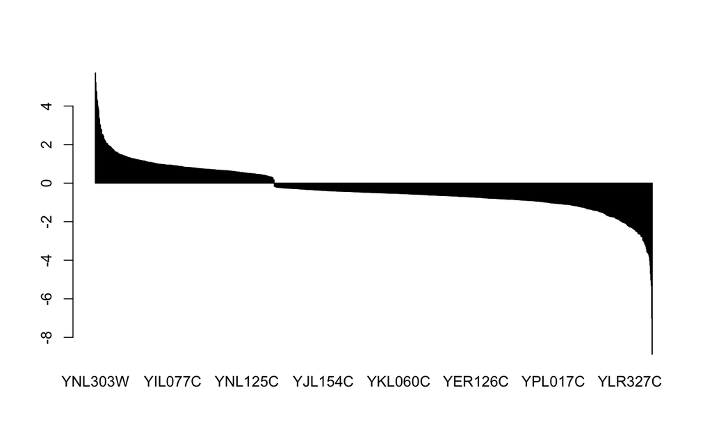

```r
# save the DE genes into a file
write.csv(as.data.frame(annotSigDEgenes), "annotSigDEgenes.csv")

# plot the range of the DE gene FC
ranks <- as.numeric(annotSigDEgenes$log2FoldChange)
names(ranks) <- annotSigDEgenes$ENSEMBL
barplot(sort(ranks, decreasing = T))
```

# 2 Visualizing RNA-seq results

## 2.1 Normalization

**Count Data Transformations:**

In order to test for differential expression, we operate on raw counts. However for other downstream analyses – e.g. for visualization or clustering – it might be useful to work with transformed versions of the count data.

**rlog**: “transforms the count data to the log2 scale in a way which minimizes differences between samples for rows with small counts, and which normalizes with respect to library size. The rlog transformation produces a similar variance stabilizing effect as varianceStabilizingTransformation, though rlog is more robust in the case when the size factors vary widely. The transformation is useful when checking for outliers or as input for machine learning techniques such as clustering or linear discriminant analysis.” – from function documentation

This is computationally very time intensive.

```r
rld <- rlog(ddsHTSeq, blind=TRUE)
head(assay(rld), 6)
```

```
##        ERR458493  ERR458494  ERR458495 ERR458500 ERR458501 ERR458502
## ETS1-1 0.0000000 0.00000000 0.00000000 0.0000000 0.0000000 0.0000000
## ETS1-2 0.0000000 0.00000000 0.00000000 0.0000000 0.0000000 0.0000000
## ETS2-1 0.0000000 0.00000000 0.00000000 0.0000000 0.0000000 0.0000000
## ETS2-2 0.0000000 0.00000000 0.00000000 0.0000000 0.0000000 0.0000000
## HRA1   0.2580976 0.09191678 0.09220481 0.1465905 0.1099255 0.1104098
## ICR1   3.8790099 3.84819131 3.85213245 3.6541824 3.9333331 4.1279316
```

**Variance stabilizing transformation (VST):** “This function calculates a variance stabilizing transformation (VST) from the fitted dispersion-mean relation(s) and then transforms the count data (normalized by division by the size factors or normalization factors), yielding a matrix of values which are now approximately homoskedastic (having constant variance along the range of mean values). The transformation also normalizes with respect to library size. The rlog is less sensitive to size factors, which can be an issue when size factors vary widely. These transformations are useful when checking for outliers or as input for machine learning techniques such as clustering or linear discriminant analysis.”" – from function documentation.

```r
vsd <- vst(ddsHTSeq, blind = TRUE)
head(assay(vsd), 6)
```

```
##        ERR458493 ERR458494 ERR458495 ERR458500 ERR458501 ERR458502
## ETS1-1  3.237951  3.237951  3.237951  3.237951  3.237951  3.237951
## ETS1-2  3.237951  3.237951  3.237951  3.237951  3.237951  3.237951
## ETS2-1  3.237951  3.237951  3.237951  3.237951  3.237951  3.237951
## ETS2-2  3.237951  3.237951  3.237951  3.237951  3.237951  3.237951
## HRA1    4.203023  3.237951  3.237951  3.771701  3.618380  3.620319
## ICR1    4.933651  4.865554  4.874110  4.511119  5.028465  5.346216
```

## 2.2 Ordination

### 2.2.1 PCA (principal component analysis) plots

rlog PCA:

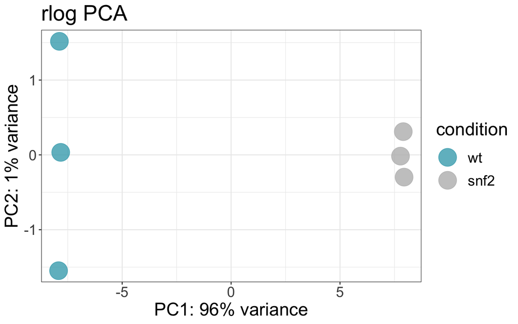

```r
data1 <- plotPCA(rld, returnData=TRUE)
data1$group<-gsub(" : ","_",as.character(data1$group))
percentVar1 <- round(100 * attr(data1, "percentVar"))

PCA<-ggplot(data1, aes(PC1, PC2, color = condition))+ theme_bw()+
  geom_point(size=9, alpha = 0.8) + scale_colour_manual(values = c("#44aabb","#bbbbbb"))+
  xlab(paste0("PC1: ",percentVar1[1],"% variance")) +
  ylab(paste0("PC2: ",percentVar1[2],"% variance")) +
  theme(text = element_text(size=20)) + ggtitle("rlog PCA")
PCA
```

```r
ggsave("figures/vsd_PCA.png", device="png") # to save the plot
```

variance stabilized PCA:

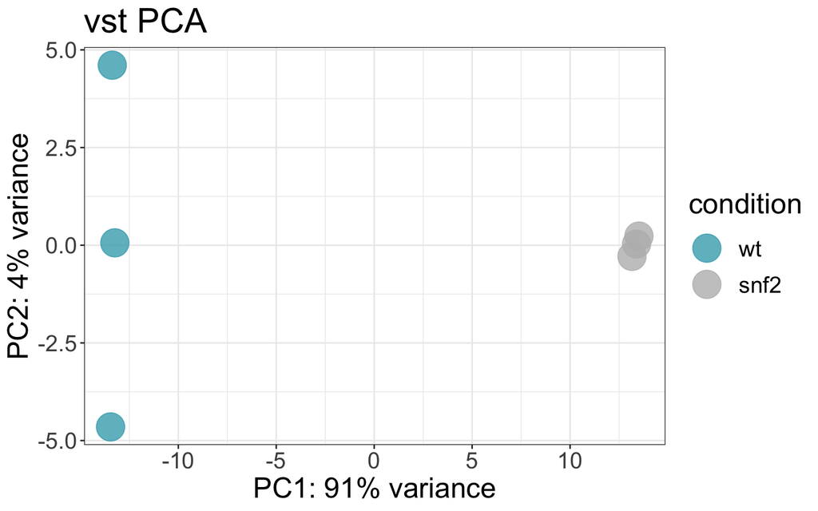

```r
data1 <- plotPCA(vsd, returnData=TRUE)
data1$group<-gsub(" : ","_",as.character(data1$group))
percentVar1 <- round(100 * attr(data1, "percentVar"))

PCA<-ggplot(data1, aes(PC1, PC2, color = condition))+ theme_bw()+
  geom_point(size=9, alpha = 0.8) + scale_colour_manual(values = c("#44aabb","#bbbbbb"))+
  xlab(paste0("PC1: ",percentVar1[1],"% variance")) +
  ylab(paste0("PC2: ",percentVar1[2],"% variance")) +
  theme(text = element_text(size=20)) + ggtitle("vst PCA")
PCA
```

```r
ggsave("figures/vsd_PCA.png", device="png") # to save the plot
```

### 2.2.2 Heatmaps

The heatmap may be combined with clustering methods which group genes and/or samples together based on the similarity of their gene expression pattern. This can be useful for identifying genes that are commonly regulated, or biological signatures associated with a particular condition (e.g a disease or an environmental condition)

rlog HeatMap:

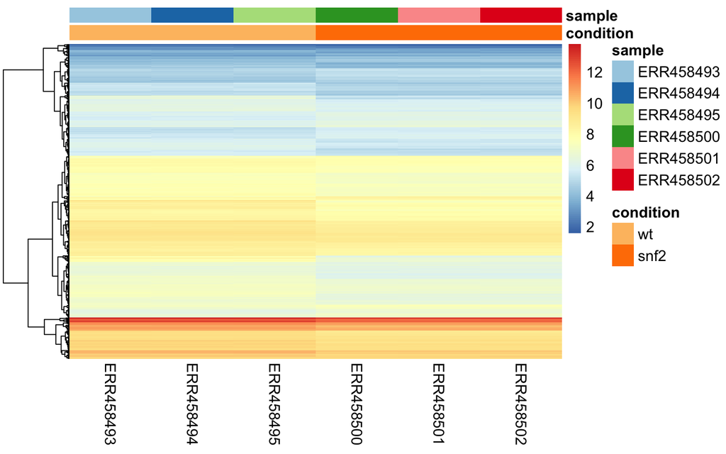

```r
df <- as.data.frame(colData(rld)[,c("condition", "sample")])

mat_colors1<-list(sample = brewer.pal(12, "Paired")[0:6])
names(mat_colors1$sample)<- df$sample

mat_colors <- list(condition = brewer.pal(12, "Paired")[7:8])
names(mat_colors$condition) <- c("wt", "snf2")

genes <- order(res$padj)[1:1000]

pheatmap(assay(rld)[genes, ], cluster_rows=TRUE, show_rownames=FALSE,
         cluster_cols=FALSE, annotation_col=df,
         annotation_colors = c(mat_colors1,mat_colors), fontsize = 12)
```

Plotting the expression level, so your counts after it was normalized.

variance stabilized HeatMap:

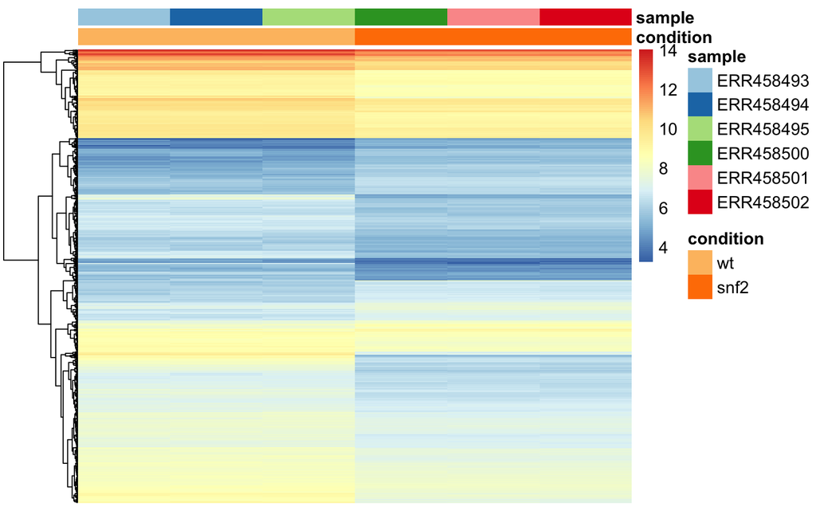

```r
df <- as.data.frame(colData(vsd)[,c("condition", "sample")])

pheatmap(assay(vsd)[genes, ], cluster_rows=TRUE, show_rownames=FALSE, show_colnames = FALSE,
         cluster_cols=FALSE, annotation_col=df,
         annotation_colors = c(mat_colors1, mat_colors), fontsize = 12)
```

Another option for heat maps: plot the difference from the mean normalized count across samples and plot the difference from the mean. (and optionally change default colors)

With Rlog transformed data:

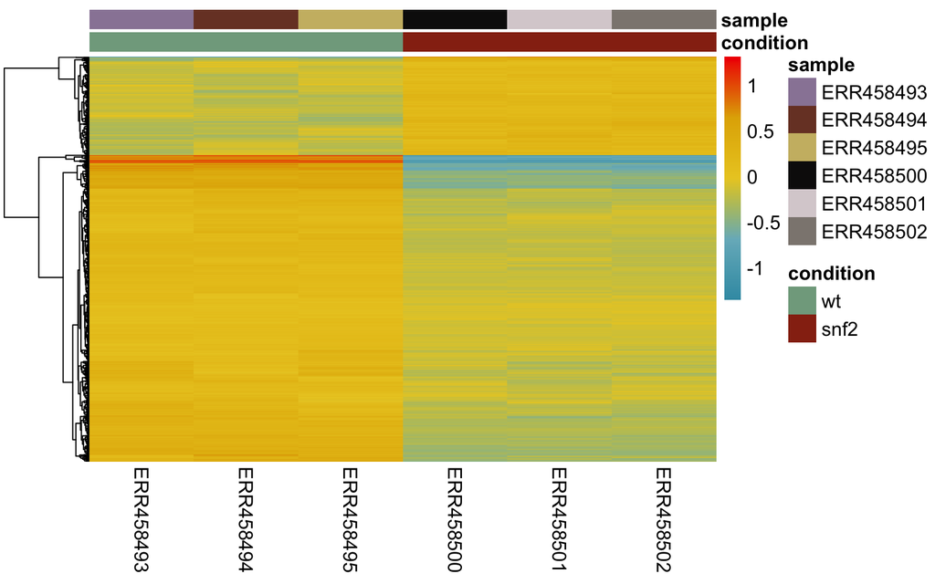

```r
library(wesanderson)
pal <- wes_palette(name = "Zissou1", n=2000 , type= "continuous")

mat_colors1<-list(sample = wes_palette("IsleofDogs1", 6))
names(mat_colors1$sample)<- df$sample

mat_colors <- list(condition = wes_palette("Cavalcanti1")[4:5])
names(mat_colors$condition) <- c("wt", "snf2")

mat <- assay(rld)[genes, ]
mat <- mat - rowMeans(mat)

df <- as.data.frame(colData(rld)[,c("condition", "sample")])

pheatmap(mat,  cluster_rows=TRUE, show_rownames=FALSE,
         cluster_cols=FALSE, annotation_col=df,
         annotation_colors = c(mat_colors1, mat_colors), fontsize = 12, color = pal)
```

Same but with variance stabilizing function:

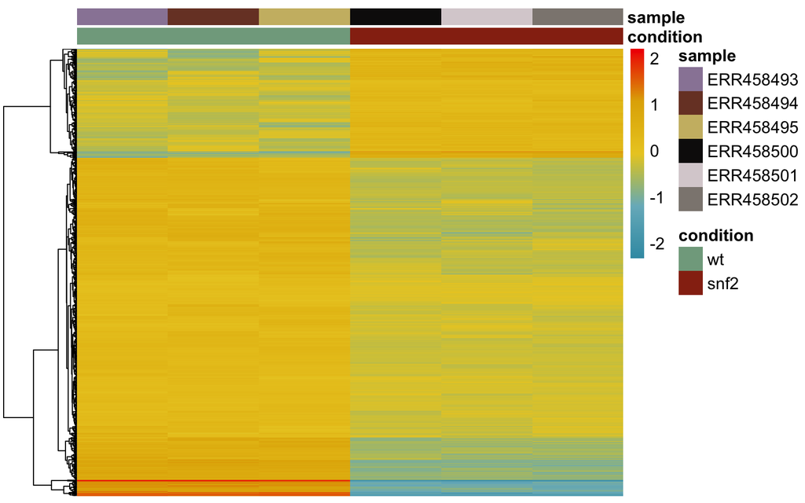

```r
mat <- assay(vsd)[genes, ]
mat <- mat - rowMeans(mat)

df <- as.data.frame(colData(vsd)[,c("condition", "sample")])

pheatmap(mat,  cluster_rows=TRUE, show_rownames=FALSE, show_colnames = FALSE,
         cluster_cols=FALSE, annotation_col=df,
         annotation_colors = c(mat_colors1, mat_colors), fontsize = 12, color = pal)
```

Heatmap of sample-to-sample distances:

A heatmap of this distance matrix gives us an overview over similarities and dissimilarities between samples.

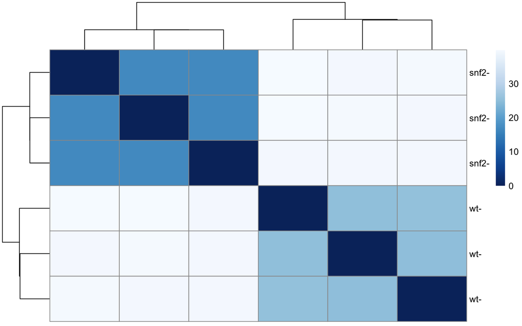

```r
sampleDists <- dist(t(assay(vsd)))
sampleDistMatrix <- as.matrix(sampleDists)
rownames(sampleDistMatrix) <- paste(vsd$condition, vsd$type, sep="-")
colnames(sampleDistMatrix) <- NULL
colors <- colorRampPalette( rev(brewer.pal(9, "Blues")) )(255)
pheatmap(sampleDistMatrix,
         clustering_distance_rows=sampleDists,
         clustering_distance_cols=sampleDists,
         col=colors)
```

## 2.3 MA plot

2-dimensional (2D) scatter plot to visualize gene expression datasets

Visualize and identify gene expression changes from two different conditions (eg. normal vs. treated) in terms of log fold change (M) on Y-axis and log of the mean of normalized expression counts of normal and treated samples (A) on X-axis.

Genes with similar expression values in both normal and treated samples will cluster around M=0 value i.e genes expressed with no significant differences in between treatments.

Points away from M=0 line indicate genes with significant expression, For example, a gene is up-regulated and down-regulated if the point is above and below M=0 line respectively.

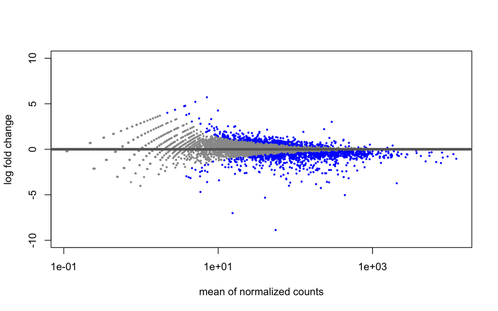

```r
DESeq2::plotMA(res, alpha = 0.05, ylim = c(-10,10)) #default alpha is 0.1
```

# 3 Gene Set Enrichment Testing

If you remember, we had 442 significantly upregulated genes and 934 significantly down regulated genes in this data set (this is pretty typical). That is a lot to try to make sense of. If you know you are interested in a specific gene or a specific pathway, you can look for that in your data, but if you are trying to figure out what is generally different between treatments, it helps to categaorize and summarize genes by what they do. Two common ways to do this are GO terms and KEGG pathways.

```r
summary(res, alpha = 0.05)
```

```
##
## out of 6531 with nonzero total read count
## adjusted p-value < 0.05
## LFC > 0 (up)       : 442, 6.8%
## LFC < 0 (down)     : 934, 14%
## outliers [1]       : 0, 0%
## low counts [2]     : 504, 7.7%
## (mean count < 2)
## [1] see 'cooksCutoff' argument of ?results
## [2] see 'independentFiltering' argument of ?results
```

## 3.1 Annotations

Get a list of DE genes:

```r
# dataframe of significantly differentially expressed genes
head(sigDEgenes)
```

```
##           baseMean log2FoldChange      lfcSE       stat       pvalue
## RUF20    12.166614      1.9713939 0.55784760   3.533929 4.094308e-04
## RUF21     3.740237      4.7796554 1.32458140   3.608427 3.080591e-04
## YAL003W 583.182692     -1.0322665 0.06507356 -15.863070 1.141738e-56
## YAL004W  65.066425     -1.9001089 0.20640509  -9.205727 3.393657e-20
## YAL005C 476.274187     -1.5024847 0.07288795 -20.613622 2.071374e-94
## YAL011W  26.679673      0.8235925 0.31158927   2.643199 8.212671e-03
##                 padj
## RUF20   2.986970e-03
## RUF21   2.320840e-03
## YAL003W 8.290669e-55
## YAL004W 9.382373e-19
## YAL005C 2.774261e-92
## YAL011W 3.852712e-02
```

```r
# add geneid column to the dataframe
sigDEgenes$geneid <- row.names(sigDEgenes)
head(sigDEgenes)
```

```
##           baseMean log2FoldChange      lfcSE       stat       pvalue
## RUF20    12.166614      1.9713939 0.55784760   3.533929 4.094308e-04
## RUF21     3.740237      4.7796554 1.32458140   3.608427 3.080591e-04
## YAL003W 583.182692     -1.0322665 0.06507356 -15.863070 1.141738e-56
## YAL004W  65.066425     -1.9001089 0.20640509  -9.205727 3.393657e-20
## YAL005C 476.274187     -1.5024847 0.07288795 -20.613622 2.071374e-94
## YAL011W  26.679673      0.8235925 0.31158927   2.643199 8.212671e-03
##                 padj  geneid
## RUF20   2.986970e-03   RUF20
## RUF21   2.320840e-03   RUF21
## YAL003W 8.290669e-55 YAL003W
## YAL004W 9.382373e-19 YAL004W
## YAL005C 2.774261e-92 YAL005C
## YAL011W 3.852712e-02 YAL011W
```

```r
# get a list of up-regulated genes and save in a file
upregged <- subset(sigDEgenes, log2FoldChange > 0)
head(upregged)
```

```
##           baseMean log2FoldChange      lfcSE     stat       pvalue         padj
## RUF20    12.166614      1.9713939 0.55784760 3.533929 4.094308e-04 0.0029869697
## RUF21     3.740237      4.7796554 1.32458140 3.608427 3.080591e-04 0.0023208400
## YAL011W  26.679673      0.8235925 0.31158927 2.643199 8.212671e-03 0.0385271249
## YAL031C  50.048974      0.9242848 0.23020658 4.015023 5.943994e-05 0.0005229847
## YAL053W 306.223119      0.3344663 0.09576589 3.492541 4.784475e-04 0.0034288733
## YAL054C  33.660241      0.9760814 0.28016606 3.483939 4.940923e-04 0.0035283108
##          geneid
## RUF20     RUF20
## RUF21     RUF21
## YAL011W YAL011W
## YAL031C YAL031C
## YAL053W YAL053W
## YAL054C YAL054C
```

```r
# and save in a file
write.csv(upregged, "up-regulatedDEgenes.csv")
```

```r
# get a list of down-regulated genes
downregged <- subset(sigDEgenes, log2FoldChange < 0)
head(downregged)
```

```
##          baseMean log2FoldChange      lfcSE       stat       pvalue
## YAL003W 583.18269     -1.0322665 0.06507356 -15.863070 1.141738e-56
## YAL004W  65.06643     -1.9001089 0.20640509  -9.205727 3.393657e-20
## YAL005C 476.27419     -1.5024847 0.07288795 -20.613622 2.071374e-94
## YAL012W 448.42081     -0.3839868 0.07371752  -5.208895 1.899687e-07
## YAL021C  86.55727     -0.5076732 0.16098672  -3.153510 1.613196e-03
## YAL023C 268.28594     -0.2837006 0.09721811  -2.918186 3.520737e-03
##                 padj  geneid
## YAL003W 8.290669e-55 YAL003W
## YAL004W 9.382373e-19 YAL004W
## YAL005C 2.774261e-92 YAL005C
## YAL012W 2.405339e-06 YAL012W
## YAL021C 9.890879e-03 YAL021C
## YAL023C 1.916846e-02 YAL023C
```

```r
# and save in a file
write.csv(downregged, "down-regulatedDEgenes.csv")
```

## 3.2 Gene Ontology (GO) Enrichment analysis

Gene ontology (http://www.geneontology.org/) provides a controlled vocabulary for describing biological processes (BP ontology), molecular functions (MF ontology) and cellular components (CC ontology)

The GO ontologies themselves are organism-independent; terms are associated with genes for a specific organism through direct experimentation or through sequence homology with another organism and its GO annotation.

Terms are related to other terms through parent-child relationships in a directed acylic graph.

Enrichment analysis provides one way of drawing conclusions about a set of differential expression results.

Create topGOData object for down-regulated genes:

```r
geneList <- as.numeric(downregged$pvalue)
names(geneList) <- downregged$geneid
# head(geneList)

selection <- function(allScore){return(allScore < 0.05)}
allGO2genes <- annFUN.org(whichOnto="BP",
                          feasibleGenes=NULL,
                          mapping="org.Sc.sgd.db", ID="ENSEMBL")

GOdata <- new("topGOdata",
              description = "GO analysis for down-regulated genes; WT vs. snf",
              ontology = "BP",
              allGenes = geneList,
              annot=annFUN.GO2genes,
              GO2genes=allGO2genes,
              geneSel = selection,
              nodeSize = 10)
```

```
##
## Building most specific GOs .....
```

```
##  ( 1328 GO terms found. )
```

```
##
## Build GO DAG topology ..........
```

```
##  ( 3047 GO terms and 6576 relations. )
```

```
##
## Annotating nodes ...............
```

```
##  ( 874 genes annotated to the GO terms. )
```

```r
GOdata
```

```
##
## ------------------------- topGOdata object -------------------------
##
##  Description:
##    -  GO analysis for down-regulated genes; WT vs. snf
##
##  Ontology:
##    -  BP
##
##  934 available genes (all genes from the array):
##    - symbol:  YAL003W YAL004W YAL005C YAL012W YAL021C  ...
##    - score :  1.1417e-56 3.3937e-20 2.0714e-94 1.8997e-07 0.0016132  ...
##    - 934  significant genes.
##
##  874 feasible genes (genes that can be used in the analysis):
##    - symbol:  YAL003W YAL005C YAL012W YAL021C YAL023C  ...
##    - score :  1.1417e-56 2.0714e-94 1.8997e-07 0.0016132 0.0035207  ...
##    - 874  significant genes.
##
##  GO graph (nodes with at least  10  genes):
##    - a graph with directed edges
##    - number of nodes = 656
##    - number of edges = 1289
##
## ------------------------- topGOdata object -------------------------
```

First, we perform a classical enrichment analysis by testing the over-representation of GO terms within the group of differentially expressed genes.

```r
resultFisher <- runTest(GOdata, algorithm = "classic", statistic = "fisher")
```

```
##
##           -- Classic Algorithm --
##
##       the algorithm is scoring 656 nontrivial nodes
##       parameters:
##           test statistic: fisher
```

```r
resultFisher
```

```
##
## Description: GO analysis for down-regulated genes; WT vs. snf
## Ontology: BP
## 'classic' algorithm with the 'fisher' test
## 656 GO terms scored: 0 terms with p < 0.01
## Annotation data:
##     Annotated genes: 874
##     Significant genes: 874
##     Min. no. of genes annotated to a GO: 10
##     Nontrivial nodes: 656
```

We will test the enrichment using the Kolmogorov-Smirnov test. We will use the both the classic and the elim method.

```r
resultKS <- runTest(GOdata, algorithm = "classic", statistic = "ks")
```

```
##
##           -- Classic Algorithm --
##
##       the algorithm is scoring 656 nontrivial nodes
##       parameters:
##           test statistic: ks
##           score order: increasing
```

```r
resultKS
```

```
##
## Description: GO analysis for down-regulated genes; WT vs. snf
## Ontology: BP
## 'classic' algorithm with the 'ks' test
## 656 GO terms scored: 86 terms with p < 0.01
## Annotation data:
##     Annotated genes: 874
##     Significant genes: 874
##     Min. no. of genes annotated to a GO: 10
##     Nontrivial nodes: 656
```

```r
resultKS.elim <- runTest(GOdata, algorithm = "elim", statistic = "ks")
```

```
##
##           -- Elim Algorithm --
##
##       the algorithm is scoring 656 nontrivial nodes
##       parameters:
##           test statistic: ks
##           cutOff: 0.01
##           score order: increasing
```

```
##
##   Level 14:  4 nodes to be scored    (0 eliminated genes)
```

```
##
##   Level 13:  7 nodes to be scored    (0 eliminated genes)
```

```
##
##   Level 12:  12 nodes to be scored   (34 eliminated genes)
```

```
##
##   Level 11:  22 nodes to be scored   (45 eliminated genes)
```

```
##
##   Level 10:  36 nodes to be scored   (45 eliminated genes)
```

```
##
##   Level 9:   57 nodes to be scored   (61 eliminated genes)
```

```
##
##   Level 8:   69 nodes to be scored   (184 eliminated genes)
```

```
##
##   Level 7:   85 nodes to be scored   (199 eliminated genes)
```

```
##
##   Level 6:   115 nodes to be scored  (294 eliminated genes)
```

```
##
##   Level 5:   115 nodes to be scored  (321 eliminated genes)
```

```
##
##   Level 4:   80 nodes to be scored   (331 eliminated genes)
```

```
##
##   Level 3:   43 nodes to be scored   (332 eliminated genes)
```

```
##
##   Level 2:   10 nodes to be scored   (393 eliminated genes)
```

```
##
##   Level 1:   1 nodes to be scored    (393 eliminated genes)
```

```r
resultKS.elim
```

```
##
## Description: GO analysis for down-regulated genes; WT vs. snf
## Ontology: BP
## 'elim' algorithm with the 'ks : 0.01' test
## 656 GO terms scored: 16 terms with p < 0.01
## Annotation data:
##     Annotated genes: 874
##     Significant genes: 874
##     Min. no. of genes annotated to a GO: 10
##     Nontrivial nodes: 656
```

Analyse results:

```r
allRes <- GenTable(GOdata, classicFisher = resultFisher,
                   classicKS = resultKS, elimKS = resultKS.elim,
                   orderBy = "elimKS", ranksOf = "classicFisher", topNodes = 100)
head(allRes)
```

```
##        GO.ID                               Term Annotated Significant Expected
## 1 GO:0006096                 glycolytic process        19          19       19
## 2 GO:0006094                    gluconeogenesis        10          10       10
## 3 GO:0031505 fungal-type cell wall organization        41          41       41
## 4 GO:0006188           IMP biosynthetic process        11          11       11
## 5 GO:0006730       one-carbon metabolic process        10          10       10
## 6 GO:0006407           rRNA export from nucleus        15          15       15
##   Rank in classicFisher classicFisher classicKS  elimKS
## 1                     1             1   8.6e-07 8.6e-07
## 2                     2             1   3.1e-05 3.1e-05
## 3                     3             1   0.00044 0.00044
## 4                     4             1   0.00047 0.00047
## 5                     5             1   0.00078 0.00078
## 6                     6             1   0.00134 0.00134
```

```r
# save results in a file
write.csv(allRes, "EnrichedGOterms.csv")
```

Plot the results:

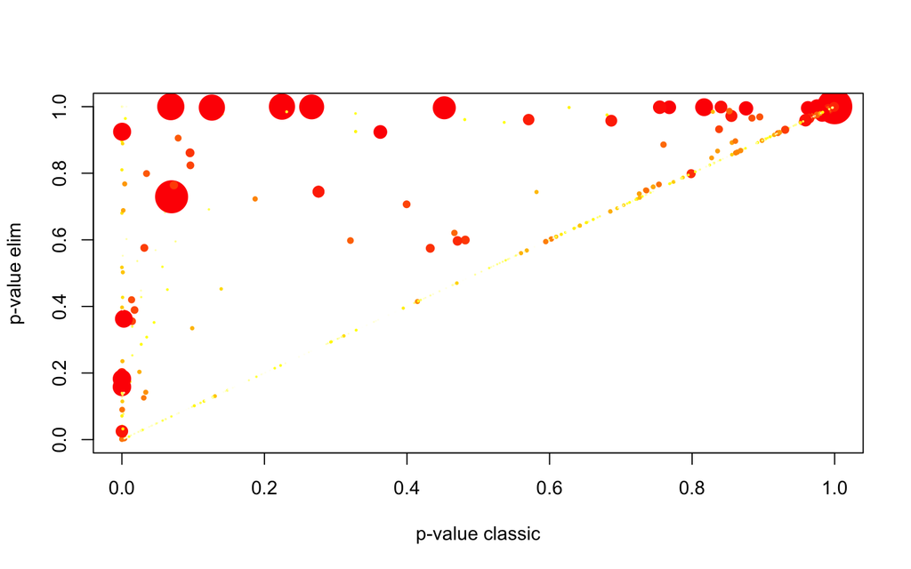

```r
pValue.classic <- score(resultKS)
pValue.elim <- score(resultKS.elim)[names(pValue.classic)]
gstat <- termStat(GOdata, names(pValue.classic))
gSize <- gstat$Annotated / max(gstat$Annotated) * 4

#Defined colMap, ref. https://github.com/Bioconductor-mirror/topGO/blob/master/vignettes/topGO.Rnw
colMap <- function(x) {
  .col <- rep(rev(heat.colors(length(unique(x)))), time = table(x))
  return(.col[match(1:length(x), order(x))])
}

gCol <- colMap(gstat$Significant)
plot(pValue.classic, pValue.elim, xlab = "p-value classic", ylab = "p-value elim",
     pch = 19, cex = gSize, col = gCol)
```

Fugure: P-values scatter plot for the classic (x axis) and elim (y axis) methods. The size of the dot is proportional with the number of annotated genes for the respective GO term and its coloring represents the number of significantly differentially expressed genes, with the dark red points having more genes then the yellow ones.

Another insightful way of looking at the results of the analysis is to investigate how the significant GO terms are distributed over the GO graph.

The structure of GO can be described in terms of a graph, where each GO term is a node, and the relationships between the terms are edges between the nodes. GO is loosely hierarchical, with ‘child’ terms being more specialized than their ‘parent’ terms, but unlike a strict hierarchy, a term may have more than one parent term.

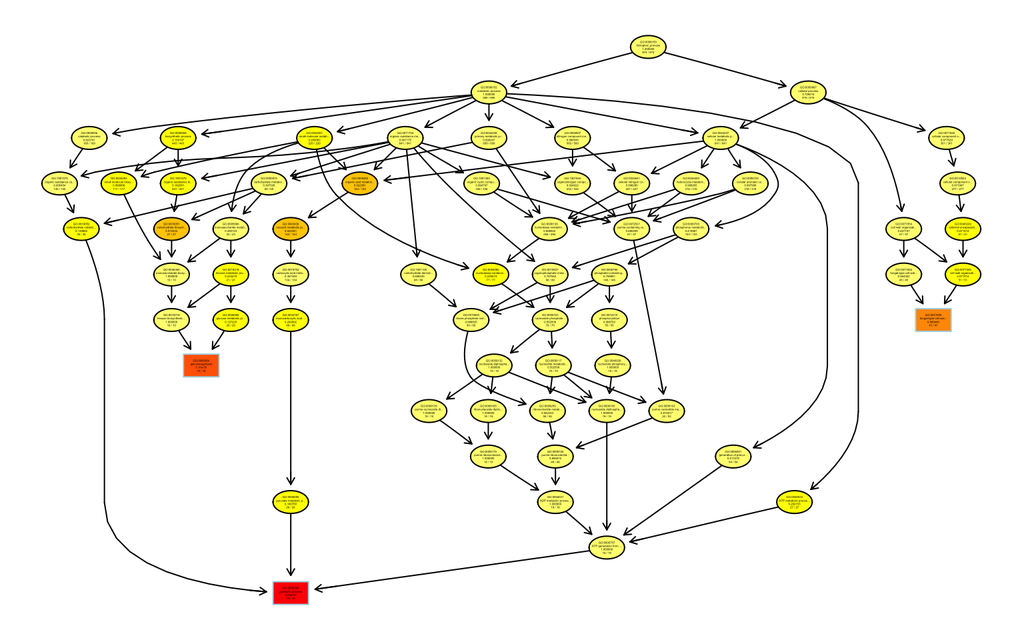

```
## $dag
## A graphNEL graph with directed edges
## Number of Nodes = 64
## Number of Edges = 107
##
## $complete.dag
## [1] "A graph with 64 nodes."
```

```r
showSigOfNodes(GOdata, score(resultKS.elim), firstSigNodes = 3, useInfo = 'all')
```

Figure: The subgraph induced by the top 3 GO terms identified by the elim algorithm for scoring GO terms for enrichment. Rectangles indicate the 3 most significant terms. Rectangle color represents the relative significance, ranging from dark red (most significant) to bright yellow (least significant). For each node, some basic information is displayed. The first two lines show the GO identifier and a trimmed GO name. In the third line the raw p-value is shown. The forth line is showing the number of significant genes and the total number of genes annotated to the respective GO term.

Create a subtable for resultKS.elim only

```r
goEnrichment <- GenTable(GOdata, elimKS = resultKS.elim, orderBy = "elimKS", topNodes=100)
goEnrichment$elimKS <- as.numeric(goEnrichment$elimKS)
goEnrichment <- goEnrichment[goEnrichment$elimKS<0.01,] # filter terms for elimKS p<0.01
goEnrichment <- goEnrichment[,c("GO.ID","Term","elimKS")]
#goEnrichment$Term <- gsub(" [a-z]*\\.\\.\\.$", "", goEnrichment$Term)
#goEnrichment$Term <- gsub("\\.\\.\\.$", "", goEnrichment$Term)
goEnrichment$Term <- paste(goEnrichment$GO.ID, goEnrichment$Term, sep=", ")
goEnrichment$Term <- factor(goEnrichment$Term, levels=rev(goEnrichment$Term))
goEnrichment
```

```
##         GO.ID                                                    Term   elimKS
## 1  GO:0006096                          GO:0006096, glycolytic process 8.60e-07
## 2  GO:0006094                             GO:0006094, gluconeogenesis 3.10e-05
## 3  GO:0031505          GO:0031505, fungal-type cell wall organization 4.40e-04
## 4  GO:0006188                    GO:0006188, IMP biosynthetic process 4.70e-04
## 5  GO:0006730                GO:0006730, one-carbon metabolic process 7.80e-04
## 6  GO:0006407                    GO:0006407, rRNA export from nucleus 1.34e-03
## 7  GO:0055114                 GO:0055114, oxidation-reduction process 1.41e-03
## 8  GO:0002181                     GO:0002181, cytoplasmic translation 3.43e-03
## 9  GO:1901606          GO:1901606, alpha-amino acid catabolic process 3.57e-03
## 10 GO:0009067 GO:0009067, aspartate family amino acid biosynthetic... 3.60e-03
## 11 GO:0006520       GO:0006520, cellular amino acid metabolic process 3.87e-03
## 12 GO:0098739               GO:0098739, import across plasma membrane 5.01e-03
## 13 GO:0071470         GO:0071470, cellular response to osmotic stress 5.33e-03
## 14 GO:0009250                 GO:0009250, glucan biosynthetic process 6.37e-03
## 15 GO:0006112            GO:0006112, energy reserve metabolic process 6.37e-03
## 16 GO:0044262     GO:0044262, cellular carbohydrate metabolic process 8.94e-03
```

Plot:

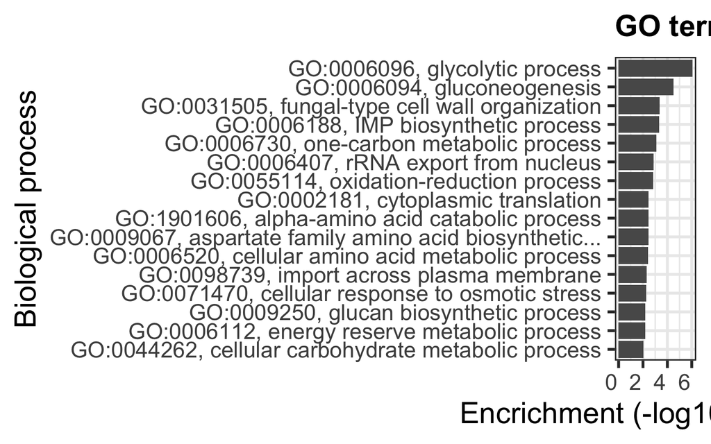

```r
require(ggplot2)
ggplot(goEnrichment, aes(x=Term, y=-log10(elimKS))) +
    stat_summary(geom = "bar", fun = mean, position = "dodge") +
    xlab("Biological process") +
    ylab("Encrichment (-log10(p-value))") +
    ggtitle("GO terms enriched in down-regulated genes") +
    scale_y_continuous(breaks = round(seq(0, max(-log10(goEnrichment$elimKS)), by = 2), 1)) +
    theme_bw(base_size=24) +
    theme(
        legend.position='none',
        legend.background=element_rect(),
        plot.title=element_text(angle=0, size=24, vjust=1, face="bold"),
        axis.text.x=element_text(angle=0, size=18, hjust=1.10),
        axis.text.y=element_text(angle=0, size=18, vjust=0.5),
        axis.title=element_text(size=24),
        legend.key=element_blank(),     #removes the border
        legend.key.size=unit(1, "cm"),      #Sets overall area/size of the legend
        legend.text=element_text(size=18),  #Text size
        title=element_text(size=18)) +
    guides(colour=guide_legend(override.aes=list(size=2.5))) +
    coord_flip()
```

```r
ggsave("figures/down_reg_enrGOterms.png", device="png")
```

## 3.3 GUI Options

David: https://david.ncifcrf.gov/gene2gene.jsp

GOrilla: http://cbl-gorilla.cs.technion.ac.il/

Special for organisms: https://www.yeastgenome.org/goTermFinder

## 3.4 KEGG

KEGG annotation and pathway enrichment is another type of functional enrichment that can be more useful than GO terms. https://www.kegg.jp/

some useful KEGG tools:

- function `kegga` in edgeR package (bioconductor)
- pathview package (bioconductor)
- iPath3, interactive: https://pathways.embl.de/